# TMDB Movies Investigation

- Introduction
- Data Wrangling
- Exploratory Data Analysis
- Conclusions

## Introduction

#### Dataset: TMDB movie dataset, I choosed this dataset especially becase it has a lot of features as it has more than 5000 movies and their rating and basic information, including user ratings and revenue data, which can be easly interpret some insights.

#### Insights:

- Which are the Columns that are highley Correlated
- Highest Movies Profit Percentage based on (Cost vs Revenue)
- How Director affect Movies Profit
- Highest Production Companies in terms of (Budget-Revenue-Profit)
- Top 10 Companies have the Highest Profit
- Highest Rated Movies Companies
- Effect of Least Counts of Movies Rating
- Most popular genres year to year
- Genres Revenues over years
- Budget / Revenue relationship for each Genre
- How Runtime affect the Rating

## Data Wrangling

```python
# Using only [pandas, numpy, matplotlib]
import numpy as np
import pandas as pd
import matplotlib.pyplot as plt
```

### General Properties

Reading the data and displaying a sample of it as well as some related-info.

```python
%matplotlib inline
DF = pd.read_csv('tmdb-movies.csv', parse_dates=['release_date'])
```

```python
DF.head()
```

|  | id | imdb_id | popularity | budget | revenue | original_title | cast | homepage | director | tagline | ... | overview | runtime | genres | production_companies | release_date | vote_count | vote_average | release_year | budget_adj | revenue_adj |
| --- | --- | --- | --- | --- | --- | --- | --- | --- | --- | --- | --- | --- | --- | --- | --- | --- | --- | --- | --- | --- | --- |
| 0 | 135397 | tt0369610 | 32.985763 | 150000000 | 1513528810 | Jurassic World | Chris Pratt\|Bryce Dallas Howard\|Irrfan Khan\|Vi... | http://www.jurassicworld.com/ | Colin Trevorrow | The park is open. | ... | Twenty-two years after the events of Jurassic ... | 124 | Action\|Adventure\|Science Fiction\|Thriller | Universal Studios\|Amblin Entertainment\|Legenda... | 2015-06-09 | 5562 | 6.5 | 2015 | 1.379999e+08 | 1.392446e+09 |
| 1 | 76341 | tt1392190 | 28.419936 | 150000000 | 378436354 | Mad Max: Fury Road | Tom Hardy\|Charlize Theron\|Hugh Keays-Byrne\|Nic... | http://www.madmaxmovie.com/ | George Miller | What a Lovely Day. | ... | An apocalyptic story set in the furthest reach... | 120 | Action\|Adventure\|Science Fiction\|Thriller | Village Roadshow Pictures\|Kennedy Miller Produ... | 2015-05-13 | 6185 | 7.1 | 2015 | 1.379999e+08 | 3.481613e+08 |
| 2 | 262500 | tt2908446 | 13.112507 | 110000000 | 295238201 | Insurgent | Shailene Woodley\|Theo James\|Kate Winslet\|Ansel... | http://www.thedivergentseries.movie/#insurgent | Robert Schwentke | One Choice Can Destroy You | ... | Beatrice Prior must confront her inner demons ... | 119 | Adventure\|Science Fiction\|Thriller | Summit Entertainment\|Mandeville Films\|Red Wago... | 2015-03-18 | 2480 | 6.3 | 2015 | 1.012000e+08 | 2.716190e+08 |
| 3 | 140607 | tt2488496 | 11.173104 | 200000000 | 2068178225 | Star Wars: The Force Awakens | Harrison Ford\|Mark Hamill\|Carrie Fisher\|Adam D... | http://www.starwars.com/films/star-wars-episod... | J.J. Abrams | Every generation has a story. | ... | Thirty years after defeating the Galactic Empi... | 136 | Action\|Adventure\|Science Fiction\|Fantasy | Lucasfilm\|Truenorth Productions\|Bad Robot | 2015-12-15 | 5292 | 7.5 | 2015 | 1.839999e+08 | 1.902723e+09 |
| 4 | 168259 | tt2820852 | 9.335014 | 190000000 | 1506249360 | Furious 7 | Vin Diesel\|Paul Walker\|Jason Statham\|Michelle ... | http://www.furious7.com/ | James Wan | Vengeance Hits Home | ... | Deckard Shaw seeks revenge against Dominic Tor... | 137 | Action\|Crime\|Thriller | Universal Pictures\|Original Film\|Media Rights ... | 2015-04-01 | 2947 | 7.3 | 2015 | 1.747999e+08 | 1.385749e+09 |

5 rows × 21 columns

## One Dimensional Exploration [Mean, Mode, Skewness]

```
    Budget, Revenue, Runtime and Release Year Columns
```

```python
print('Budget: [', 'Mean:', DF['budget'].mean(), '\tMode:', DF['budget'].mode()[0], '\tSkew:', DF['budget'].skew(),']')
```

```
Budget: [ Mean: 14625701.09414688 	Mode: 0 	Skew: 3.7172370567347603 ]
```

```python
print('Revenue: [', 'Mean:', DF['revenue'].mean(), '\tMode:', DF['revenue'].mode()[0], '\tSkew:', DF['revenue'].skew(),']')
```

```
Revenue: [ Mean: 39823319.79339223 	Mode: 0 	Skew: 6.658397231320427 ]
```

```python
print('Runtime: [', 'Mean:', DF['runtime'].mean(), '\tMode:', DF['runtime'].mode()[0], '\tSkew:', DF['runtime'].skew(),']')
```

```
Runtime: [ Mean: 102.07086324314375 	Mode: 90 	Skew: 6.103792811316886 ]
```

```python
print('Release Year: [', 'Mean:', DF['release_year'].mean(), '\tMode:', DF['release_year'].mode()[0], '\tSkew:', DF['release_year'].skew(),']')
```

```
Release Year: [ Mean: 2001.3226578317688 	Mode: 2014 	Skew: -1.204254293629925 ]
```

```
Histogram Plotting Budget, Revenue & Runtime
```

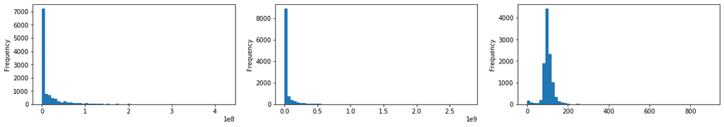

```python
fig, axes = plt.subplots(1, 3,figsize=(20, 3))
DF['budget'].plot(kind='hist',bins = 60, ax=axes[0])
DF['revenue'].plot(kind='hist',bins = 60, ax=axes[1])
DF['runtime'].plot(kind='hist',bins = 60, ax=axes[2])
plt.show()
```

Counting **Zero Values**

```python
print('Budget Count: ', len(DF[DF['budget'] == 0]['budget']), 'Revenue Count: ', len(DF[DF['revenue'] == 0]['revenue']), 'Runtime Count: ', len(DF[DF['runtime'] == 0]['runtime']))
```

```
Budget Count:  5696 Revenue Count:  6016 Runtime Count:  31
```

- Half of the data in Budget and Revenue Columns is Zero.

## Two Dimensional Exploration

#### Information about the data including number of values in each column and their types

```python
DF.info()
```

```
<class 'pandas.core.frame.DataFrame'>
RangeIndex: 10866 entries, 0 to 10865
Data columns (total 21 columns):
id                      10866 non-null int64
imdb_id                 10856 non-null object
popularity              10866 non-null float64
budget                  10866 non-null int64
revenue                 10866 non-null int64
original_title          10866 non-null object
cast                    10790 non-null object
homepage                2936 non-null object
director                10822 non-null object
tagline                 8042 non-null object
keywords                9373 non-null object
overview                10862 non-null object
runtime                 10866 non-null int64
genres                  10843 non-null object
production_companies    9836 non-null object
release_date            10866 non-null datetime64[ns]
vote_count              10866 non-null int64
vote_average            10866 non-null float64
release_year            10866 non-null int64
budget_adj              10866 non-null float64
revenue_adj             10866 non-null float64
dtypes: datetime64[ns](1), float64(4), int64(6), object(10)
memory usage: 1.7+ MB
```

#### Statistical information about the data like, count, mean, min and max.

```python
DF.describe()
```

|  | id | popularity | budget | revenue | runtime | vote_count | vote_average | release_year | budget_adj | revenue_adj |
| --- | --- | --- | --- | --- | --- | --- | --- | --- | --- | --- |
| count | 10866.000000 | 10866.000000 | 1.086600e+04 | 1.086600e+04 | 10866.000000 | 10866.000000 | 10866.000000 | 10866.000000 | 1.086600e+04 | 1.086600e+04 |
| mean | 66064.177434 | 0.646441 | 1.462570e+07 | 3.982332e+07 | 102.070863 | 217.389748 | 5.974922 | 2001.322658 | 1.755104e+07 | 5.136436e+07 |
| std | 92130.136561 | 1.000185 | 3.091321e+07 | 1.170035e+08 | 31.381405 | 575.619058 | 0.935142 | 12.812941 | 3.430616e+07 | 1.446325e+08 |
| min | 5.000000 | 0.000065 | 0.000000e+00 | 0.000000e+00 | 0.000000 | 10.000000 | 1.500000 | 1960.000000 | 0.000000e+00 | 0.000000e+00 |
| 25% | 10596.250000 | 0.207583 | 0.000000e+00 | 0.000000e+00 | 90.000000 | 17.000000 | 5.400000 | 1995.000000 | 0.000000e+00 | 0.000000e+00 |
| 50% | 20669.000000 | 0.383856 | 0.000000e+00 | 0.000000e+00 | 99.000000 | 38.000000 | 6.000000 | 2006.000000 | 0.000000e+00 | 0.000000e+00 |
| 75% | 75610.000000 | 0.713817 | 1.500000e+07 | 2.400000e+07 | 111.000000 | 145.750000 | 6.600000 | 2011.000000 | 2.085325e+07 | 3.369710e+07 |
| max | 417859.000000 | 32.985763 | 4.250000e+08 | 2.781506e+09 | 900.000000 | 9767.000000 | 9.200000 | 2015.000000 | 4.250000e+08 | 2.827124e+09 |

## Data Cleaning (Nulls - Duplications - Invalid Values)

### Searching for Nulls

```python
DF.isnull().sum()
```

```
id                         0
imdb_id                   10
popularity                 0
budget                     0
revenue                    0
original_title             0
cast                      76
homepage                7930
director                  44
tagline                 2824
keywords                1493
overview                   4
runtime                    0
genres                    23
production_companies    1030
release_date               0
vote_count                 0
vote_average               0
release_year               0
budget_adj                 0
revenue_adj                0
dtype: int64
```

There are too many Nulls in the data, The remaining rows after removing the Nulls will be 1992, which will be too risky so instead, I will not remove the Nulls but i will remove columns like [homepage,tagline,keywords] which have a lot of Nulls as it wouldn't be an issue in our needed insights

## Dropping Unneeded Columns

```python
DF.drop(DF.columns[[7, 9, 10]], axis=1, inplace=True)
print(DF.columns.tolist())
```

```
['id', 'imdb_id', 'popularity', 'budget', 'revenue', 'original_title', 'cast', 'director', 'overview', 'runtime', 'genres', 'production_companies', 'release_date', 'vote_count', 'vote_average', 'release_year', 'budget_adj', 'revenue_adj']
```

## Replacing Null Values

Here we will replace null values of 'genres' column

```python
DF['genres'].isnull().sum()
```

```
23
```

```python
DF["genres"].fillna("No genre", inplace = True)
```

```python
DF['genres'].isnull().sum()
```

```
0
```

This repalcing will help us while exploratory data of 'genres' column

And that hepls also in removing duplicated data

## Searching for Invalid Values

Looking in Data description, I've noticed some columns have a minimum value of Zeros, which they shouldn't have, let's count those values

```python
print('Movie Runtime = 0:\t\t\t', len(DF[DF['runtime'] == 0]))
print('Movie Budget = 0:\t\t\t', len(DF[DF['budget'] == 0]))
print('Movie Revenue = 0:\t\t\t', len(DF[DF['revenue'] == 0]))
print('Movie Budget < 150 and Revenue > 0:\t', len(DF[(DF['budget'] < 150) & (DF['revenue'] > 0)]))
```

```
Movie Runtime = 0:			 31
Movie Budget = 0:			 5696
Movie Revenue = 0:			 6016
Movie Budget < 150 and Revenue > 0:	 1017
```

```
So we can drop rows that has a runtime = 0 but we can't drop the budget or revenue =0, however some of the movies have a budget less than 150 dollars but have high revenues which doesn't make a sense, i googled them and found out most of them have invalid values, so we can drop them too.
```

## Removing Invalid Values

```python
DF.drop(DF[DF.runtime == 0].index, inplace=True)
DF.drop(DF[(DF['budget'] < 150) & (DF['revenue'] > 0)].index, inplace=True)
len(DF)
```

```
9818
```

## Searching for Nulls again

```python
DF.isnull().sum()
```

```
id                        0
imdb_id                  10
popularity                0
budget                    0
revenue                   0
original_title            0
cast                     75
director                 42
overview                  2
runtime                   0
genres                    0
production_companies    961
release_date              0
vote_count                0
vote_average              0
release_year              0
budget_adj                0
revenue_adj               0
dtype: int64
```

## Dropping Nulls

```python
DF.dropna(inplace=True)
len(DF), sum(DF.isnull().sum().values)
```

```
(8799, 0)
```

## Exploratory Data Analysis

### Feature Engineering

```
Adding two additional colums for [Profit and Percentage Profit]
```

```python
# Calculating the Profit
DF['Profit'] = DF['revenue']-DF['budget']
# Calculating Profit Percentage
DF['ProPer'] = DF['Profit']/DF['budget']*100
#Replacing [inf,Nulls] with 0
DF['ProPer'] = DF['ProPer'].replace([np.inf, -np.inf], np.nan).fillna(0).astype(int)
```

```
Function for Sorting the DataFrame & Plotting Bar Chart
```

```python
def Sorting(df,column,order):
    df = df.sort_values(by=[column], ascending=order)
    return df

def Plot(title, ylabel, x, y, c):
    plt.figure(figsize=(16, 6))
    plt.title(title, fontsize=18)
    plt.bar(x, y, color=c, alpha=0.7)
    plt.ylabel(ylabel); plt.xticks(rotation=90, size=8)
    plt.show()
```

### Which are the Columns that are highly Correlated

```python
DF.corr()
```

|  | id | popularity | budget | revenue | runtime | vote_count | vote_average | release_year | budget_adj | revenue_adj | Profit | ProPer |
| --- | --- | --- | --- | --- | --- | --- | --- | --- | --- | --- | --- | --- |
| id | 1.000000 | -0.006266 | -0.145482 | -0.095223 | -0.099845 | -0.032963 | -0.099918 | 0.499349 | -0.199984 | -0.135864 | -0.069232 | -0.011032 |
| popularity | -0.006266 | 1.000000 | 0.540144 | 0.665287 | 0.163484 | 0.804075 | 0.250037 | 0.107211 | 0.506148 | 0.611215 | 0.633537 | 0.011570 |
| budget | -0.145482 | 0.540144 | 1.000000 | 0.733684 | 0.226170 | 0.624954 | 0.107566 | 0.140561 | 0.967426 | 0.620117 | 0.571466 | -0.008238 |
| revenue | -0.095223 | 0.665287 | 0.733684 | 1.000000 | 0.188324 | 0.789970 | 0.203134 | 0.078365 | 0.705041 | 0.918511 | 0.976883 | 0.028730 |
| runtime | -0.099845 | 0.163484 | 0.226170 | 0.188324 | 1.000000 | 0.191828 | 0.195748 | -0.133128 | 0.263804 | 0.203120 | 0.156285 | -0.009962 |
| vote_count | -0.032963 | 0.804075 | 0.624954 | 0.789970 | 0.191828 | 1.000000 | 0.292040 | 0.122873 | 0.577642 | 0.707633 | 0.757435 | 0.016061 |
| vote_average | -0.099918 | 0.250037 | 0.107566 | 0.203134 | 0.195748 | 0.292040 | 1.000000 | -0.151375 | 0.122910 | 0.225553 | 0.211485 | 0.010622 |
| release_year | 0.499349 | 0.107211 | 0.140561 | 0.078365 | -0.133128 | 0.122873 | -0.151375 | 1.000000 | 0.031214 | -0.046777 | 0.050421 | -0.003271 |
| budget_adj | -0.199984 | 0.506148 | 0.967426 | 0.705041 | 0.263804 | 0.577642 | 0.122910 | 0.031214 | 1.000000 | 0.645990 | 0.547122 | -0.008417 |
| revenue_adj | -0.135864 | 0.611215 | 0.620117 | 0.918511 | 0.203120 | 0.707633 | 0.225553 | -0.046777 | 0.645990 | 1.000000 | 0.914198 | 0.033154 |
| Profit | -0.069232 | 0.633537 | 0.571466 | 0.976883 | 0.156285 | 0.757435 | 0.211485 | 0.050421 | 0.547122 | 0.914198 | 1.000000 | 0.037289 |
| ProPer | -0.011032 | 0.011570 | -0.008238 | 0.028730 | -0.009962 | 0.016061 | 0.010622 | -0.003271 | -0.008417 | 0.033154 | 0.037289 | 1.000000 |

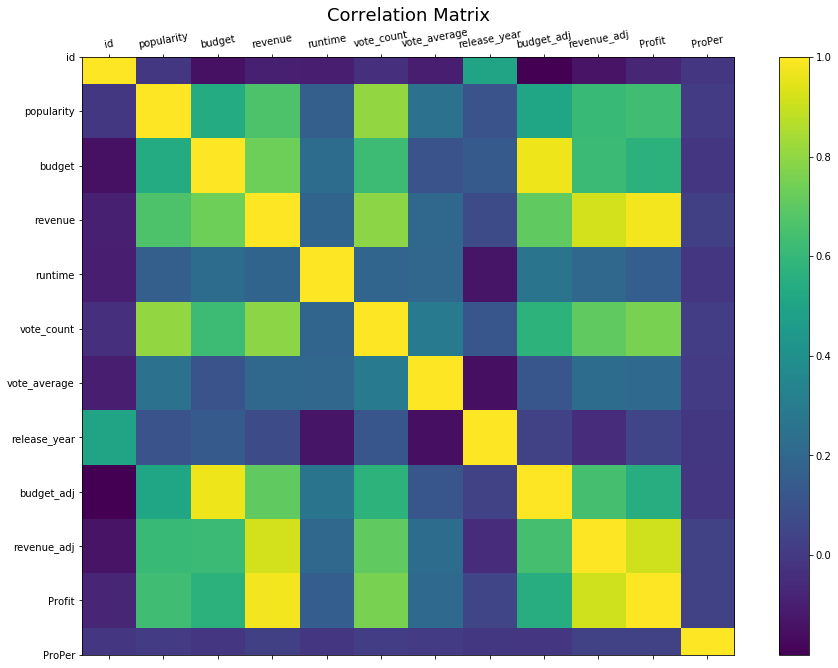

```python
plt.figure(figsize=(16, 11))
plt.matshow(DF.corr(), fignum=0)
plt.title('Correlation Matrix', fontsize=18)
plt.xticks(range(DF.select_dtypes(['number']).shape[1]), DF.select_dtypes(['number']).columns, rotation=10)
plt.yticks(range(DF.select_dtypes(['number']).shape[1]), DF.select_dtypes(['number']).columns)
plt.colorbar();
```

```
There is a correlation between budget and popularity, revenue and popularity, revenue and budget, vote count and popularity, vote count and revenue
```

### Highest Movies Profit Percentage based on (Cost vs Revenue)

```
1- Profit
```

```python
ProDF = Sorting(DF,'Profit',False)
ProDF.head()
```

|  | id | imdb_id | popularity | budget | revenue | original_title | cast | director | overview | runtime | genres | production_companies | release_date | vote_count | vote_average | release_year | budget_adj | revenue_adj | Profit | ProPer |
| --- | --- | --- | --- | --- | --- | --- | --- | --- | --- | --- | --- | --- | --- | --- | --- | --- | --- | --- | --- | --- |
| 1386 | 19995 | tt0499549 | 9.432768 | 237000000 | 2781505847 | Avatar | Sam Worthington\|Zoe Saldana\|Sigourney Weaver\|S... | James Cameron | In the 22nd century, a paraplegic Marine is di... | 162 | Action\|Adventure\|Fantasy\|Science Fiction | Ingenious Film Partners\|Twentieth Century Fox ... | 2009-12-10 | 8458 | 7.1 | 2009 | 2.408869e+08 | 2.827124e+09 | 2544505847 | 1073 |
| 3 | 140607 | tt2488496 | 11.173104 | 200000000 | 2068178225 | Star Wars: The Force Awakens | Harrison Ford\|Mark Hamill\|Carrie Fisher\|Adam D... | J.J. Abrams | Thirty years after defeating the Galactic Empi... | 136 | Action\|Adventure\|Science Fiction\|Fantasy | Lucasfilm\|Truenorth Productions\|Bad Robot | 2015-12-15 | 5292 | 7.5 | 2015 | 1.839999e+08 | 1.902723e+09 | 1868178225 | 934 |
| 5231 | 597 | tt0120338 | 4.355219 | 200000000 | 1845034188 | Titanic | Kate Winslet\|Leonardo DiCaprio\|Frances Fisher\|... | James Cameron | 84 years later, a 101-year-old woman named Ros... | 194 | Drama\|Romance\|Thriller | Paramount Pictures\|Twentieth Century Fox Film ... | 1997-11-18 | 4654 | 7.3 | 1997 | 2.716921e+08 | 2.506406e+09 | 1645034188 | 822 |
| 0 | 135397 | tt0369610 | 32.985763 | 150000000 | 1513528810 | Jurassic World | Chris Pratt\|Bryce Dallas Howard\|Irrfan Khan\|Vi... | Colin Trevorrow | Twenty-two years after the events of Jurassic ... | 124 | Action\|Adventure\|Science Fiction\|Thriller | Universal Studios\|Amblin Entertainment\|Legenda... | 2015-06-09 | 5562 | 6.5 | 2015 | 1.379999e+08 | 1.392446e+09 | 1363528810 | 909 |
| 4 | 168259 | tt2820852 | 9.335014 | 190000000 | 1506249360 | Furious 7 | Vin Diesel\|Paul Walker\|Jason Statham\|Michelle ... | James Wan | Deckard Shaw seeks revenge against Dominic Tor... | 137 | Action\|Crime\|Thriller | Universal Pictures\|Original Film\|Media Rights ... | 2015-04-01 | 2947 | 7.3 | 2015 | 1.747999e+08 | 1.385749e+09 | 1316249360 | 692 |

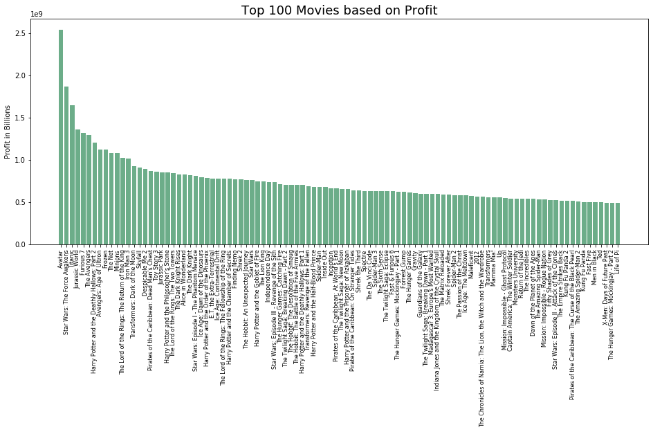

```python
Plot('Top 100 Movies based on Profit', 'Profit in Billions', ProDF['original_title'][:100], ProDF['Profit'][:100], 'seagreen')
```

[output not shown]

```python
PercDF = Sorting(DF,'ProPer',False)
PercDF.head()
```

|  | id | imdb_id | popularity | budget | revenue | original_title | cast | director | overview | runtime | genres | production_companies | release_date | vote_count | vote_average | release_year | budget_adj | revenue_adj | Profit | ProPer |
| --- | --- | --- | --- | --- | --- | --- | --- | --- | --- | --- | --- | --- | --- | --- | --- | --- | --- | --- | --- | --- |
| 7447 | 23827 | tt1179904 | 1.120442 | 15000 | 193355800 | Paranormal Activity | Katie Featherston\|Micah Sloat\|Mark Fredrichs\|A... | Oren Peli | After a young, middle class couple moves into ... | 86 | Horror\|Mystery | Blumhouse Productions\|Solana Films | 2007-09-14 | 714 | 6.1 | 2007 | 15775.028739 | 2.033462e+08 | 193340800 | 1288938 |
| 2449 | 2667 | tt0185937 | 0.934621 | 25000 | 248000000 | The Blair Witch Project | Heather Donahue\|Michael C. Williams\|Joshua Leo... | Daniel Myrick\|Eduardo SÃ¡nchez | In October of 1994 three student filmmakers di... | 81 | Horror\|Mystery | Artisan Entertainment\|Haxan Films | 1999-07-14 | 522 | 6.3 | 1999 | 32726.321165 | 3.246451e+08 | 247975000 | 991900 |
| 1354 | 985 | tt0074486 | 0.331417 | 10000 | 7000000 | Eraserhead | Jack Nance\|Charlotte Stewart\|Allen Joseph\|Jean... | David Lynch | Henry Spencer tries to survive his industrial ... | 89 | Science Fiction\|Fantasy\|Horror\|Drama | American Film Institute (AFI)\|Libra Films | 1977-03-19 | 194 | 7.1 | 1977 | 35977.810326 | 2.518447e+07 | 6990000 | 69900 |
| 7277 | 692 | tt0069089 | 0.412913 | 12000 | 6000000 | Pink Flamingos | Divine\|David Lochary\|Mary Vivian Pearce\|Mink S... | John Waters | Notorious Baltimore criminal and underground f... | 93 | Comedy | Dreamland Productions | 1972-03-12 | 51 | 6.3 | 1972 | 62574.731176 | 3.128737e+07 | 5988000 | 49900 |
| 7178 | 9372 | tt0390521 | 0.263897 | 65000 | 28575078 | Super Size Me | Morgan Spurlock\|Daryl Isaacs\|Lisa Ganjhu\|Steph... | Morgan Spurlock | Morgan Spurlock subjects himself to a diet bas... | 100 | Documentary\|Comedy\|Drama | Kathbur Pictures | 2004-01-17 | 295 | 6.5 | 2004 | 75038.950988 | 3.298837e+07 | 28510078 | 43861 |

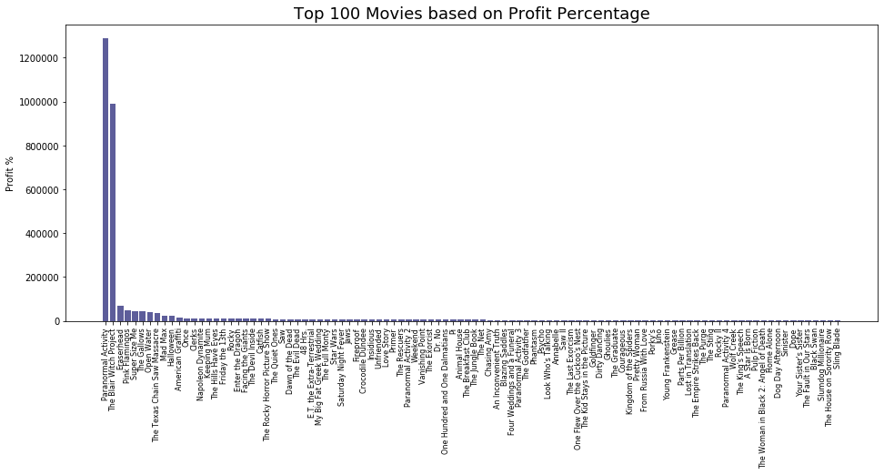

```python
Plot('Top 100 Movies based on Profit Percentage', 'Profit %', PercDF['original_title'][:100], PercDF['ProPer'][:100], 'midnightblue')
```

```
On the contrary Paranomal Activity, The Blair, and Eraserhead was on the top of Profit Percentage list, while Avatar is not in this list, maybe it's cost of production was too high too.
```

### How Director affect Movies Profit

```python
# Group by director then summing all movies profit percentages
DirDF = Sorting(DF.groupby('director').sum(),'ProPer',False)
DirDF.head()
```

| director | id | popularity | budget | revenue | runtime | vote_count | vote_average | release_year | budget_adj | revenue_adj | Profit | ProPer |
| --- | --- | --- | --- | --- | --- | --- | --- | --- | --- | --- | --- | --- |
| Oren Peli | 81703 | 1.489971 | 5015000 | 193355800 | 177 | 796 | 10.5 | 4022 | 4.615773e+06 | 2.033462e+08 | 188340800 | 1288838 |
| Daniel Myrick\|Eduardo SÃ¡nchez | 2667 | 0.934621 | 25000 | 248000000 | 81 | 522 | 6.3 | 1999 | 3.272632e+04 | 3.246451e+08 | 247975000 | 991900 |
| David Lynch | 239068 | 10.096949 | 110510000 | 115001420 | 1204 | 2573 | 75.6 | 21873 | 1.924988e+08 | 2.364689e+08 | 4491420 | 70194 |
| John Waters | 87125 | 2.265957 | 49037000 | 24001197 | 725 | 381 | 47.7 | 15920 | 6.763507e+07 | 5.879796e+07 | -25035803 | 49550 |
| Morgan Spurlock | 186109 | 0.586694 | 10065000 | 28575078 | 285 | 442 | 20.4 | 6025 | 9.435372e+06 | 3.298837e+07 | 18510078 | 43761 |

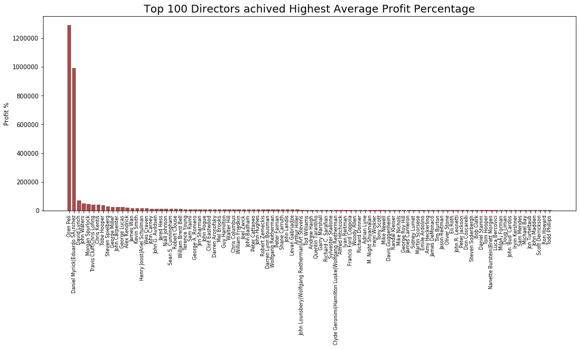

```python
Plot('Top 100 Directors achived Highest Average Profit Percentage', 'Profit %', DirDF.index[:100], DirDF['ProPer'][:100], 'maroon')
```

[output not shown]

### Highest Production Companies in terms of (Budget-Revenue-Profit)

```python
CoDF = DF.copy(deep=True)
# Splitting ['production_companies'] String into array of values
CoDF['production_companies'] = CoDF['production_companies'].str.split('|').tolist()
```

```python
CoDF.head()
```

|  | id | imdb_id | popularity | budget | revenue | original_title | cast | director | overview | runtime | genres | production_companies | release_date | vote_count | vote_average | release_year | budget_adj | revenue_adj | Profit | ProPer |
| --- | --- | --- | --- | --- | --- | --- | --- | --- | --- | --- | --- | --- | --- | --- | --- | --- | --- | --- | --- | --- |
| 0 | 135397 | tt0369610 | 32.985763 | 150000000 | 1513528810 | Jurassic World | Chris Pratt\|Bryce Dallas Howard\|Irrfan Khan\|Vi... | Colin Trevorrow | Twenty-two years after the events of Jurassic ... | 124 | Action\|Adventure\|Science Fiction\|Thriller | [Universal Studios, Amblin Entertainment, Lege... | 2015-06-09 | 5562 | 6.5 | 2015 | 1.379999e+08 | 1.392446e+09 | 1363528810 | 909 |
| 1 | 76341 | tt1392190 | 28.419936 | 150000000 | 378436354 | Mad Max: Fury Road | Tom Hardy\|Charlize Theron\|Hugh Keays-Byrne\|Nic... | George Miller | An apocalyptic story set in the furthest reach... | 120 | Action\|Adventure\|Science Fiction\|Thriller | [Village Roadshow Pictures, Kennedy Miller Pro... | 2015-05-13 | 6185 | 7.1 | 2015 | 1.379999e+08 | 3.481613e+08 | 228436354 | 152 |
| 2 | 262500 | tt2908446 | 13.112507 | 110000000 | 295238201 | Insurgent | Shailene Woodley\|Theo James\|Kate Winslet\|Ansel... | Robert Schwentke | Beatrice Prior must confront her inner demons ... | 119 | Adventure\|Science Fiction\|Thriller | [Summit Entertainment, Mandeville Films, Red W... | 2015-03-18 | 2480 | 6.3 | 2015 | 1.012000e+08 | 2.716190e+08 | 185238201 | 168 |
| 3 | 140607 | tt2488496 | 11.173104 | 200000000 | 2068178225 | Star Wars: The Force Awakens | Harrison Ford\|Mark Hamill\|Carrie Fisher\|Adam D... | J.J. Abrams | Thirty years after defeating the Galactic Empi... | 136 | Action\|Adventure\|Science Fiction\|Fantasy | [Lucasfilm, Truenorth Productions, Bad Robot] | 2015-12-15 | 5292 | 7.5 | 2015 | 1.839999e+08 | 1.902723e+09 | 1868178225 | 934 |
| 4 | 168259 | tt2820852 | 9.335014 | 190000000 | 1506249360 | Furious 7 | Vin Diesel\|Paul Walker\|Jason Statham\|Michelle ... | James Wan | Deckard Shaw seeks revenge against Dominic Tor... | 137 | Action\|Crime\|Thriller | [Universal Pictures, Original Film, Media Righ... | 2015-04-01 | 2947 | 7.3 | 2015 | 1.747999e+08 | 1.385749e+09 | 1316249360 | 692 |

```
1. Budget
```

```python
# Exploding each array value into independent row, grouping by 'production_companies' and getting sum of Budget
Budget = Sorting(CoDF.explode('production_companies').groupby('production_companies').sum(),'budget',False)
Budget.head()
```

| production_companies | id | popularity | budget | revenue | runtime | vote_count | vote_average | release_year | budget_adj | revenue_adj | Profit | ProPer |
| --- | --- | --- | --- | --- | --- | --- | --- | --- | --- | --- | --- | --- |
| Warner Bros. | 12393650 | 565.419086 | 19984610367 | 52450110812 | 52540 | 273610 | 2839.8 | 914383 | 2.428118e+10 | 6.696881e+10 | 32465500445 | 85748 |
| Universal Pictures | 13839999 | 472.722162 | 15559559993 | 46223972833 | 50513 | 208575 | 2818.5 | 924722 | 1.905047e+10 | 6.047437e+10 | 30664412840 | 128903 |
| Paramount Pictures | 9459584 | 392.918293 | 13810207916 | 39842684646 | 41789 | 175713 | 2323.1 | 756024 | 1.714528e+10 | 5.413069e+10 | 26032476730 | 122532 |
| Columbia Pictures | 7769933 | 272.267337 | 11352615000 | 28861963974 | 27453 | 138018 | 1492.5 | 493960 | 1.278645e+10 | 3.194263e+10 | 17509348974 | 35134 |
| Walt Disney Pictures | 7523384 | 286.346731 | 10602931000 | 32027313979 | 17969 | 132912 | 1228.0 | 398352 | 1.174779e+10 | 3.667857e+10 | 21424382979 | 32474 |

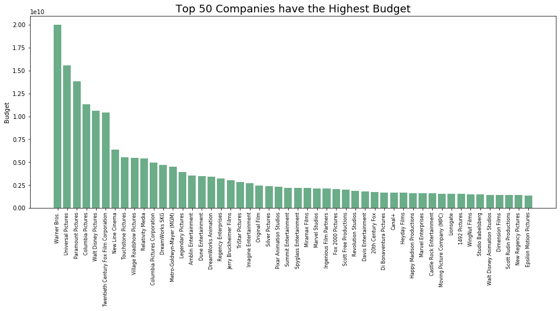

```python
Plot('Top 50 Companies have the Highest Budget', 'Budget', Budget.index[:50], Budget['budget'][:50], 'seagreen')
```

```
Higest production companies in terms of budget were warner Bros. Universal Pictures and Paramount Pictures.

2. Revenue
```

```python
# Exploding each array value into independent row, grouping by 'production_companies' and getting sum of Revenue
Revenue = Sorting(CoDF.explode('production_companies').groupby('production_companies').sum(),'revenue',False)
Revenue.head()
```

| production_companies | id | popularity | budget | revenue | runtime | vote_count | vote_average | release_year | budget_adj | revenue_adj | Profit | ProPer |
| --- | --- | --- | --- | --- | --- | --- | --- | --- | --- | --- | --- | --- |
| Warner Bros. | 12393650 | 565.419086 | 19984610367 | 52450110812 | 52540 | 273610 | 2839.8 | 914383 | 2.428118e+10 | 6.696881e+10 | 32465500445 | 85748 |
| Universal Pictures | 13839999 | 472.722162 | 15559559993 | 46223972833 | 50513 | 208575 | 2818.5 | 924722 | 1.905047e+10 | 6.047437e+10 | 30664412840 | 128903 |
| Paramount Pictures | 9459584 | 392.918293 | 13810207916 | 39842684646 | 41789 | 175713 | 2323.1 | 756024 | 1.714528e+10 | 5.413069e+10 | 26032476730 | 122532 |
| Twentieth Century Fox Film Corporation | 7361086 | 335.068684 | 10425425801 | 36806982348 | 28201 | 170130 | 1572.9 | 512660 | 1.310439e+10 | 5.037067e+10 | 26381556547 | 84820 |
| Walt Disney Pictures | 7523384 | 286.346731 | 10602931000 | 32027313979 | 17969 | 132912 | 1228.0 | 398352 | 1.174779e+10 | 3.667857e+10 | 21424382979 | 32474 |

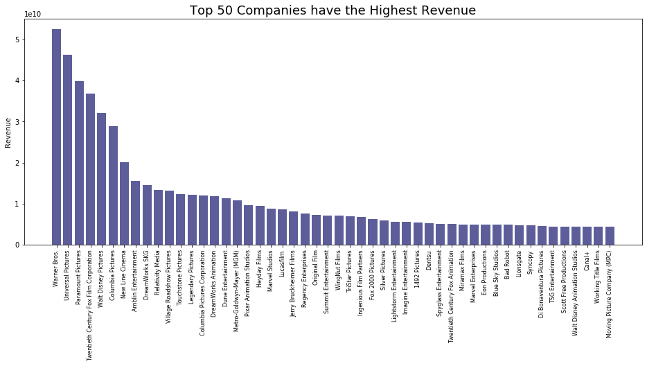

```python
Plot('Top 50 Companies have the Highest Revenue', 'Revenue', Revenue.index[:50], Revenue['revenue'][:50], 'midnightblue')
```

```
Higest production companies in terms of revenue was warner Bros. Universal Pictures and Paramount Pictures too, so they make the most costly movies and also they earn the higest revenues.

3. Profit
```

```python
# Exploding each array value into independent row, grouping by 'production_companies' and getting sum of Profit
Profit = Sorting(CoDF.explode('production_companies').groupby('production_companies').sum(),'Profit',False)
Profit.head()
```

| production_companies | id | popularity | budget | revenue | runtime | vote_count | vote_average | release_year | budget_adj | revenue_adj | Profit | ProPer |
| --- | --- | --- | --- | --- | --- | --- | --- | --- | --- | --- | --- | --- |
| Warner Bros. | 12393650 | 565.419086 | 19984610367 | 52450110812 | 52540 | 273610 | 2839.8 | 914383 | 2.428118e+10 | 6.696881e+10 | 32465500445 | 85748 |
| Universal Pictures | 13839999 | 472.722162 | 15559559993 | 46223972833 | 50513 | 208575 | 2818.5 | 924722 | 1.905047e+10 | 6.047437e+10 | 30664412840 | 128903 |
| Twentieth Century Fox Film Corporation | 7361086 | 335.068684 | 10425425801 | 36806982348 | 28201 | 170130 | 1572.9 | 512660 | 1.310439e+10 | 5.037067e+10 | 26381556547 | 84820 |
| Paramount Pictures | 9459584 | 392.918293 | 13810207916 | 39842684646 | 41789 | 175713 | 2323.1 | 756024 | 1.714528e+10 | 5.413069e+10 | 26032476730 | 122532 |
| Walt Disney Pictures | 7523384 | 286.346731 | 10602931000 | 32027313979 | 17969 | 132912 | 1228.0 | 398352 | 1.174779e+10 | 3.667857e+10 | 21424382979 | 32474 |

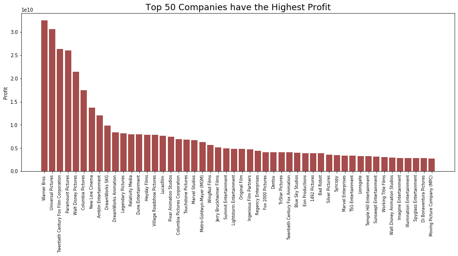

```python
Plot('Top 50 Companies have the Highest Profit', 'Profit', Profit.index[:50], Profit['Profit'][:50], 'maroon')
```

[output not shown]

### Top 10 Companies have the Highest Profit

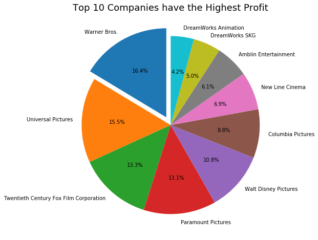

```python
plt.figure(figsize=(16, 8))
explode = (0.1, 0, 0, 0, 0, 0, 0, 0, 0, 0)
plt.title('Top 10 Companies have the Highest Profit', fontsize=18)
plt.pie(Profit.Profit[:10].values, explode=explode, labels=Profit.index[:10].values, autopct='%1.1f%%', startangle=90)
plt.show()
```

```
Top 10 Companies have the Highest Profit, where Warner Bros. in the top of this list, Universal Pictures came on the second place and Twentieth Century Fox Film came on the third place with a profit size over 45% of all other companies in the list.
```

### Highest Rated Movies Companies

```python
# Exploding each array value into independent row, grouping by 'production_companies' and getting the mean of voteing avarage
Rating = Sorting(CoDF.explode('production_companies').groupby('production_companies').mean(),'vote_average',False)
# Picking the highest rating based vote_count > 99 vote, as less than 100 will not represent the votes well
Rating = Rating[Rating['vote_count'] > 99]
Rating.head()
```

| production_companies | id | popularity | budget | revenue | runtime | vote_count | vote_average | release_year | budget_adj | revenue_adj | Profit | ProPer |
| --- | --- | --- | --- | --- | --- | --- | --- | --- | --- | --- | --- | --- |
| Alfran Productions | 238.0 | 5.738034 | 6000000.0 | 245066411.0 | 175.0 | 3970.0 | 8.3 | 1972.0 | 3.128737e+07 | 1.277914e+09 | 239066411.0 | 3984.0 |
| Linson Films | 550.0 | 8.947905 | 63000000.0 | 100853753.0 | 139.0 | 5923.0 | 8.1 | 1999.0 | 8.247033e+07 | 1.320229e+08 | 37853753.0 | 60.0 |
| Atman Entertainment | 550.0 | 8.947905 | 63000000.0 | 100853753.0 | 139.0 | 5923.0 | 8.1 | 1999.0 | 8.247033e+07 | 1.320229e+08 | 37853753.0 | 60.0 |
| Duperele Films | 264644.0 | 3.557846 | 6000000.0 | 35401758.0 | 117.0 | 1520.0 | 8.0 | 2015.0 | 5.519998e+06 | 3.256960e+07 | 29401758.0 | 490.0 |
| Bristol Automotive | 205596.0 | 8.110711 | 14000000.0 | 233555708.0 | 113.0 | 3478.0 | 8.0 | 2014.0 | 1.289527e+07 | 2.151261e+08 | 219555708.0 | 1568.0 |

```python
Rating['vote_average'][:20]
```

```
production_companies
Alfran Productions               8.3
Linson Films                     8.1
Atman Entertainment              8.1
Duperele Films                   8.0
Bristol Automotive               8.0
Metafilms                        8.0
Blue Parrot Productions          8.0
The Turman-Morrissey Company     8.0
Shamley Productions              8.0
SODEC                            8.0
Cecchi Gori Pictures             7.9
Strong Heart/Demme Production    7.9
Bulletproof Cupid                7.9
The Mirisch Company              7.9
EMJAG Productions                7.9
Heritage Films                   7.9
Dog Eat Dog Productions Inc.     7.9
Manny O Productions              7.9
Canfield Pictures                7.9
I Remember Productions           7.9
Name: vote_average, dtype: float64
```

On Highest Rated Movies Companies list, Alfran Productions came in the first place with average rating of 8.3, while Linson Films on the second place with 8.1 average rate, and Atman Entertainment in the third place with 8.1 average rating, which mean not always the highest profit or revenue companies has much higer average rating.

### Effect of Least Counts of Movies Rating

```python
Counts = Sorting(DF,'vote_count',True)
```

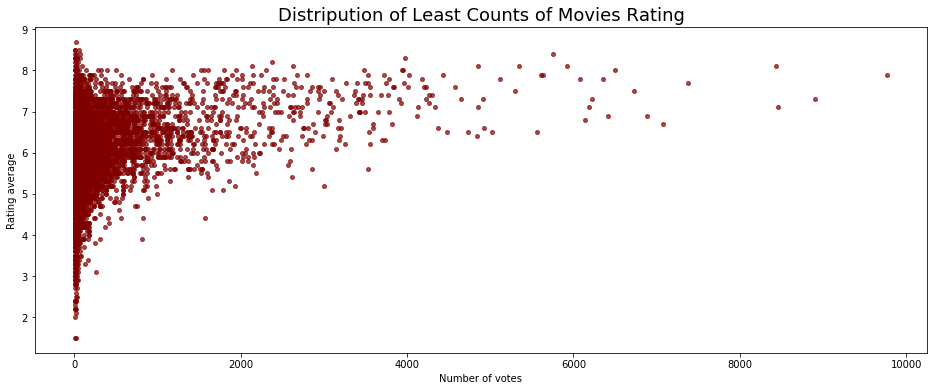

```python
plt.figure(figsize=(16, 6))
plt.title('Distripution of Least Counts of Movies Rating', fontsize=18)
plt.scatter(Counts['vote_count'], Counts['vote_average'], s=15.5, color='maroon', alpha=0.7)
plt.ylabel('Rating average'); plt.xlabel('Number of votes')
plt.show()
```

There is a slightly correlation between the number of voting and the rate of voting, which makes sense, as the number of voting represent the popularity of that particular movie in most of the cases, which translated to if that particular movie is popular so it has to be good movie.

### Most popular genres year to year

```python
# Splitting the genres column and combined it with release year and popularity cols
DF_genrs=pd.DataFrame(DF.genres.str.split('|').tolist(),index=[DF['release_year'],DF['popularity']]).stack()
```

```python
# Reset and rename the dataframe cols
DF_genrs=DF_genrs.reset_index([0,1])
DF_genrs.rename({0:'genres'},axis=1,inplace=True)  #renaming genres column
DF_sort_genrs=DF_genrs.sort_values(['popularity','release_year','genres'],ascending=False)
DF_sort_genrs.head()
```

|  | release_year | popularity | genres |
| --- | --- | --- | --- |
| 3 | 2015 | 32.985763 | Thriller |
| 2 | 2015 | 32.985763 | Science Fiction |
| 1 | 2015 | 32.985763 | Adventure |
| 0 | 2015 | 32.985763 | Action |
| 3 | 2015 | 28.419936 | Thriller |

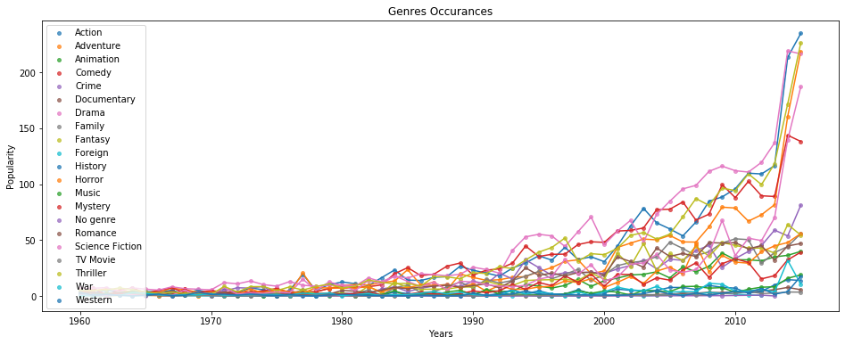

```python
## Plotting the data frame

plt.figure(figsize=(16, 6))
Genres = np.unique(DF_sort_genrs['genres']).tolist()
for i in Genres:
    Plot = DF_sort_genrs[DF_sort_genrs['genres']==i].groupby('release_year').sum()
    plt.scatter(Plot.index, Plot['popularity'], s=15.5, alpha=0.7, label=i)
    plt.plot(Plot.index, Plot['popularity'])
plt.ylabel('Popularity'); plt.xlabel('Years')
plt.title('Genres Occurances')
plt.legend()
plt.show()
```

### Genres Revenues over years

```python
## Splitting the genres column and combined it with release year and revenue cols
DF_revn=pd.DataFrame(DF.genres.str.split('|').tolist(),index=[DF['release_year'],DF['revenue']]).stack()
```

```python
# Reset and rename the dataframe cols
DF_revn=DF_revn.reset_index([0,1])
DF_revn.rename({0:'genres'},axis=1,inplace=True)  #renaming genres column
DF_sort_revn=DF_revn.sort_values(['revenue','release_year','genres'],ascending=False)
DF_sort_revn.head()
```

|  | release_year | revenue | genres |
| --- | --- | --- | --- |
| 3 | 2009 | 2781505847 | Science Fiction |
| 2 | 2009 | 2781505847 | Fantasy |
| 1 | 2009 | 2781505847 | Adventure |
| 0 | 2009 | 2781505847 | Action |
| 2 | 2015 | 2068178225 | Science Fiction |

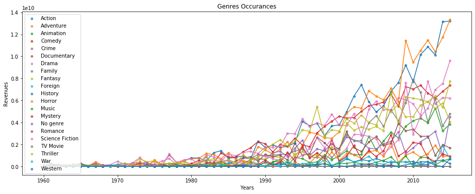

```python
## Plotting the data frame

plt.figure(figsize=(16, 6))
Genres = np.unique(DF_sort_revn['genres']).tolist()
for i in Genres:
    Plot = DF_sort_revn[DF_sort_revn['genres']==i].groupby('release_year').sum()
    plt.scatter(Plot.index, Plot['revenue'], s=15.5, alpha=0.7, label=i)
    plt.plot(Plot.index, Plot['revenue'])
plt.ylabel('Revenues'); plt.xlabel('Years')
plt.title('Genres Occurances')
plt.legend()
plt.show()
```

### Budget / Revenue relationship for each Genre

```python
DF_budg=pd.DataFrame(DF.genres.str.split('|').tolist(),index=[DF['budget'],DF['revenue']]).stack()
```

```python
DF_budg=DF_budg.reset_index([0,1])
DF_budg.rename({0:'genres'},axis=1,inplace=True)  #renaming genres column
DF_sort_budg=DF_budg.sort_values(['budget','revenue','genres'],ascending=False)
DF_plt=DF_sort_budg.groupby('genres').sum()
DF_plt.head()
```

| genres | budget | revenue |
| --- | --- | --- |
| Action | 65877888025 | 169675574854 |
| Adventure | 55101319491 | 163324842843 |
| Animation | 16148237133 | 51632976774 |
| Comedy | 50193704942 | 132011665247 |
| Crime | 23858686636 | 54769821912 |

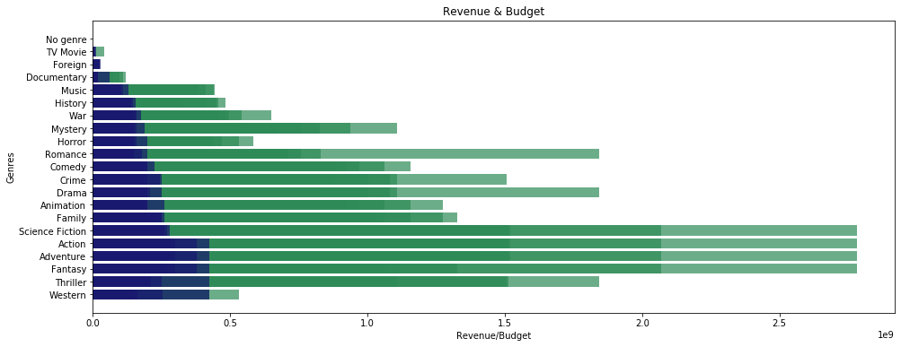

```python
plt.figure(figsize=(16, 6))
plt.barh(DF_sort_budg['genres'],DF_sort_budg['revenue'], alpha=0.7,color='seagreen')
plt.barh(DF_sort_budg['genres'],DF_sort_budg['budget'], alpha=0.7,color='midnightblue')
plt.xlabel('Revenue/Budget')
plt.ylabel('Genres')
plt.title('Revenue & Budget')
plt.show()
```

this shows that the most genres make high revenues are also (science fiction,fantasy,adventure,action)

### How Runtime affect the Rating

shows the relation between runtime and rating of the movies

```python
DF_rate=pd.DataFrame(index=[DF['runtime'],DF['vote_average']])
DF_rate2=DF_rate.sort_values(['runtime','vote_average'],ascending=False)
DF_rate2.head()
```

| runtime | vote_average |
| --- | --- |
| 877 | 6.8 |
| 566 | 8.3 |
| 540 | 7.8 |
| 500 | 7.0 |
| 470 | 6.6 |

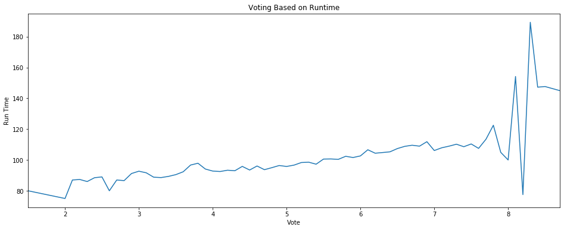

```python
plt.figure(figsize=(16, 6))
DF.groupby(['vote_average'])['runtime'].mean().plot()
plt.xlabel('Vote'); plt.ylabel('Run Time')
plt.title('Voting Based on Runtime')
plt.show()
```

that shows that the more the runtime increase the rating is increases.

## Conclusion

### Limitations

First, the data had a lot of Nulls which made it impossible to drop them all, and made it harder to do the Data Preparation, as homepage had about 7930, tagline 2824, keywords 1493, but those 3 columns were not targetet in answering the questions purposed, but on the other side there were a critical issues that needs to be discussed:

- Missing values production_companies column, it had about 1030 movies didn't labeled for a company, which i think it made a significant impact in the insights.
- Invalid values More than half of the data in some columns have invalid values like budget and revenue, which had 0 value instead of actual values, which made some companies in terms of budget, revenue and profit were not in the list or misplaced it's ranking,

as genres column we coiuldn't drop the nulls because it will make some issues in exploration so that:

- we replaced them with (no genres) to be able exploring well
- as we replaced the nulls the duplicated data are gone

Overall the data did answer most of the questions, but for the most accurate anwer it needs to be enlarged and enhanced.

Thanks a lot...